# Lab 2: Introduction to Data

Preston Peck

2021-09-10

# Introduction to Data

https://htmlpreview.github.io/?https://github.com/jbryer/DATA606/blob/master/inst/labs/Lab2/Lab2_intro_to_data.html

```r
library(tidyverse)
library(openintro)
library(psych)
```

### Exercise 1

The difference between the 3 histograms are binwidth, which corresponds to the span for ranges that data will be placed into.  
The higher the binwidth, the wider and more data per bar, which may end up masking the data’s nuance if too high.  
the lower the binwidth, the narrower and less data per bar, which may end up visually cluttering the data if too low.

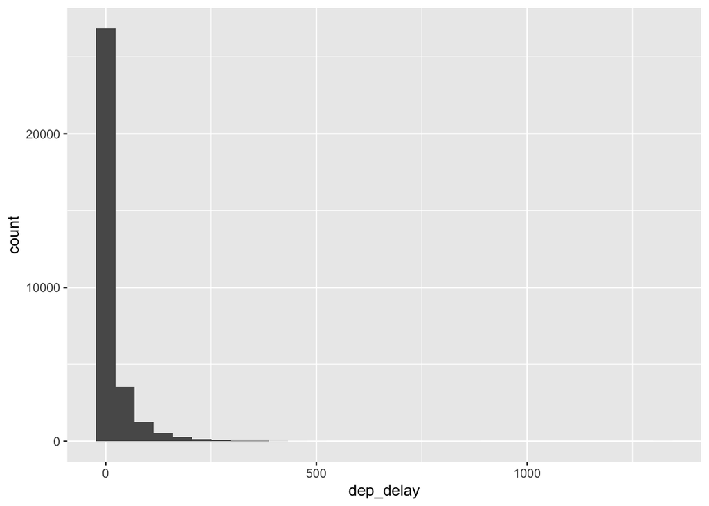

```r
ggplot(data = nycflights, aes(x = dep_delay)) +
  geom_histogram()
```

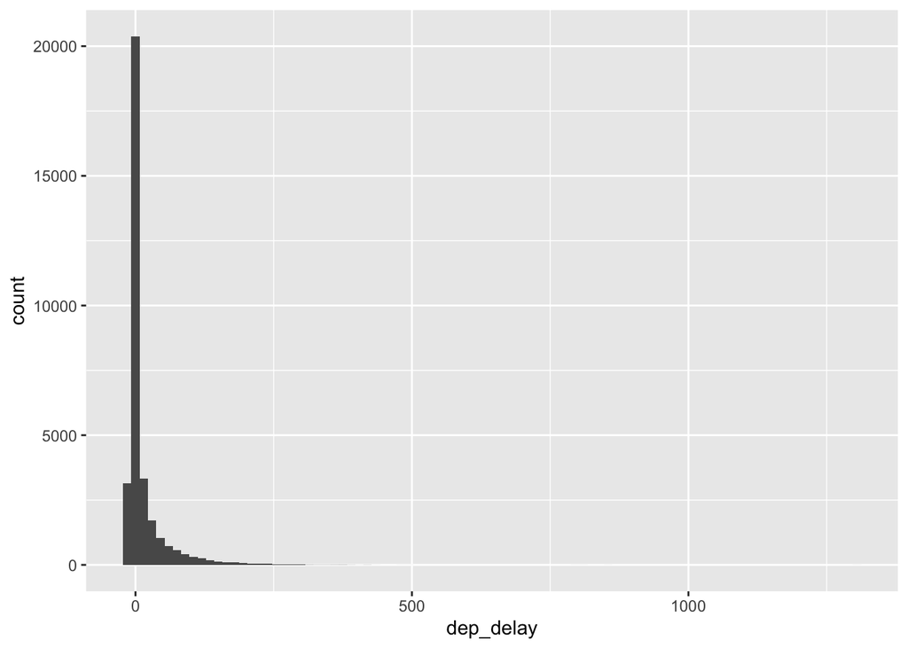

```r
ggplot(data = nycflights, aes(x = dep_delay)) +
  geom_histogram(binwidth = 15)
```

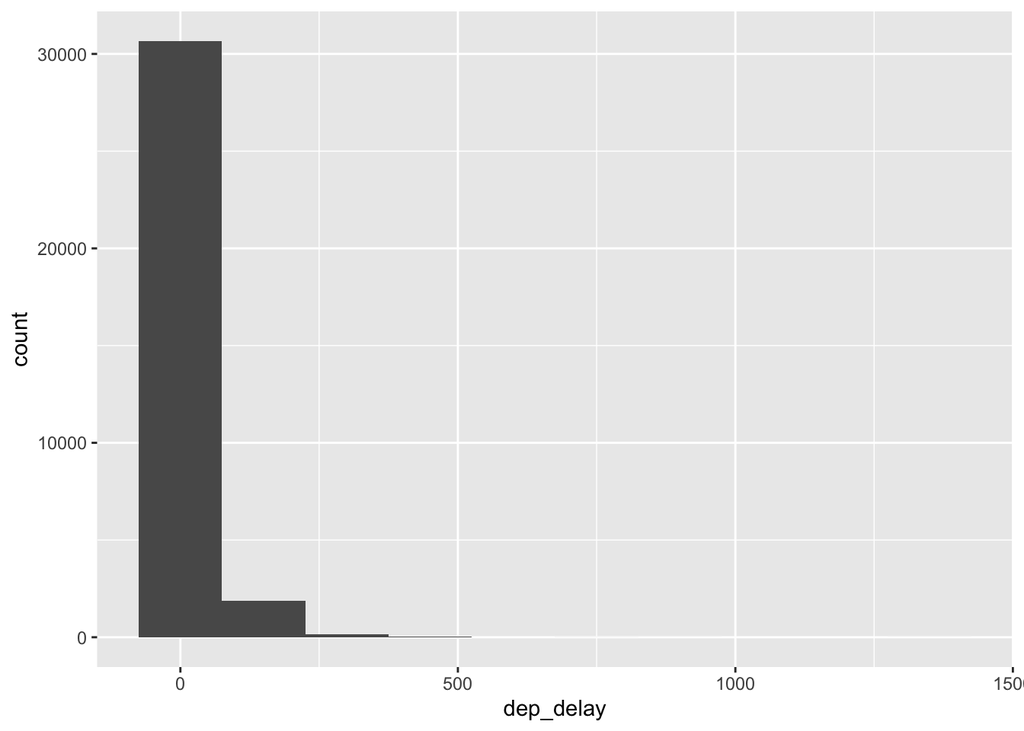

```r
ggplot(data = nycflights, aes(x = dep_delay)) +
  geom_histogram(binwidth = 150)
```

### Exercise 2

68 flights are heading to San Francisco in February

```r
sfo_feb_flights <- nycflights %>%
  filter(dest == "SFO", month == 2)

nrow(sfo_feb_flights)
```

```
## [1] 68
```

### Exercise 3

```r
nycflights$arr_delay %>%
  describe
```

```
##    vars     n mean    sd median trimmed   mad min  max range skew kurtosis   se
## X1    1 32735  7.1 44.69     -5   -0.79 20.76 -73 1272  1345 4.02    41.39 0.25
```

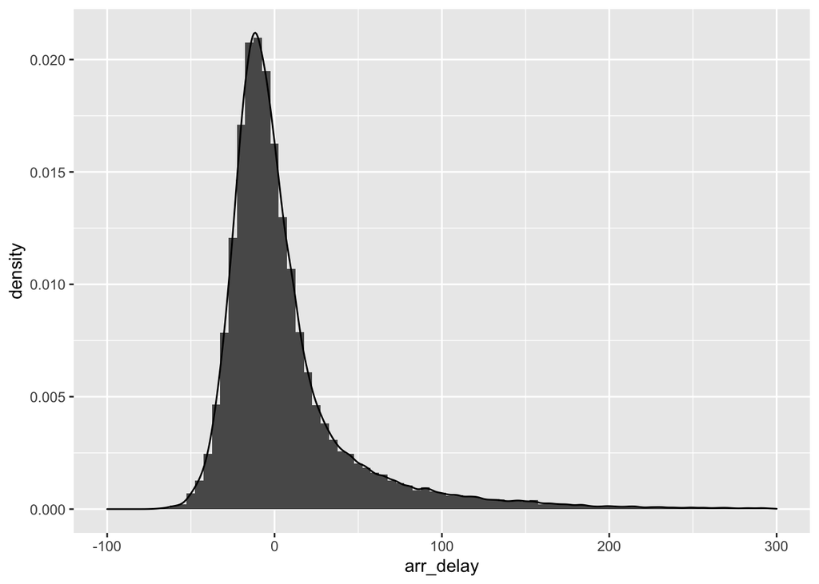

```r
ggplot(data = nycflights, aes(x = arr_delay)) +
  geom_histogram(binwidth = 5, aes(y = ..density..)) +
  geom_density() +
  xlim(-100, 300)
```

### Exercise 4

UA has the biggest range, but UA and DL are both tied with the highest interquartile range

```r
sfo_feb_flights$arr_delay %>%
  describeBy(group = sfo_feb_flights$carrier)
```

```
##
##  Descriptive statistics by group
## group: AA
##    vars  n mean    sd median trimmed   mad min max range skew kurtosis   se
## X1    1 10 11.5 29.47      5    8.12 15.57 -26  76   102 0.91    -0.21 9.32
## ------------------------------------------------------------
## group: B6
##    vars n  mean    sd median trimmed  mad min max range skew kurtosis   se
## X1    1 6 -6.33 10.98  -10.5   -6.33 7.41 -18  11    29  0.5    -1.64 4.48
## ------------------------------------------------------------
## group: DL
##    vars  n   mean    sd median trimmed   mad min max range skew kurtosis   se
## X1    1 19 -13.47 22.03    -15  -15.06 14.83 -48  48    96 0.91     1.13 5.05
## ------------------------------------------------------------
## group: UA
##    vars  n mean    sd median trimmed   mad min max range skew kurtosis    se
## X1    1 21 1.81 48.33    -10   -7.41 14.83 -35 196   231 3.05     9.49 10.55
## ------------------------------------------------------------
## group: VX
##    vars  n   mean    sd median trimmed   mad min max range skew kurtosis    se
## X1    1 12 -13.75 40.85  -22.5   -19.8 18.53 -66  99   165 1.56     2.11 11.79
```

```r
sfo_feb_flights %>%
  group_by(carrier) %>%
  summarise(iqr = IQR(arr_delay))
```

```
## # A tibble: 5 × 2
##   carrier   iqr
##   <chr>   <dbl>
## 1 AA       17.5
## 2 B6       12.2
## 3 DL       22
## 4 UA       22
## 5 VX       21.2
```

### Exercise 5

Mean would be the better representation of a set since its a calculated weighted value that can take into consideration the influence of clusters which median isn’t able to account for since it’s based on middle ordinal position regardless of patterns on either side of it.  
Based off mean, October would be the best month to fly to minimize departure delays.  
Based off median, September or October are the best months to fly to minimize departure delays.

```r
nycflights$dep_delay %>%
  describeBy(group = nycflights$month)
```

```
##
##  Descriptive statistics by group
## group: 1
##    vars    n  mean    sd median trimmed  mad min  max range  skew kurtosis   se
## X1    1 2610 10.23 42.39     -2    1.74 5.93 -17 1301  1318 12.84   335.61 0.83
## ------------------------------------------------------------
## group: 2
##    vars    n  mean    sd median trimmed  mad min max range skew kurtosis   se
## X1    1 2286 10.69 33.12     -2    3.05 5.93 -20 319   339  3.7    18.28 0.69
## ------------------------------------------------------------
## group: 3
##    vars    n  mean    sd median trimmed  mad min max range skew kurtosis   se
## X1    1 2869 13.52 40.29     -1    3.91 7.41 -20 393   413 3.85    20.05 0.75
## ------------------------------------------------------------
## group: 4
##    vars    n  mean    sd median trimmed  mad min max range skew kurtosis   se
## X1    1 2781 14.55 43.42     -2    4.08 5.93 -18 427   445 3.79    19.07 0.82
## ------------------------------------------------------------
## group: 5
##    vars    n  mean    sd median trimmed  mad min max range skew kurtosis   se
## X1    1 2821 13.26 38.25     -1    4.22 7.41 -19 351   370 3.48    15.33 0.72
## ------------------------------------------------------------
## group: 6
##    vars    n  mean    sd median trimmed mad min max range skew kurtosis   se
## X1    1 2732 20.35 53.51      0    8.18 8.9 -18 803   821 4.86    42.62 1.02
## ------------------------------------------------------------
## group: 7
##    vars    n  mean    sd median trimmed mad min max range skew kurtosis   se
## X1    1 2742 20.75 47.78      0    9.65 8.9 -17 392   409  3.1    12.28 0.91
## ------------------------------------------------------------
## group: 8
##    vars    n  mean    sd median trimmed  mad min max range skew kurtosis   se
## X1    1 2880 12.62 39.22     -1    3.26 7.41 -21 436   457 4.11    23.13 0.73
## ------------------------------------------------------------
## group: 9
##    vars    n mean    sd median trimmed  mad min max range skew kurtosis   se
## X1    1 2681 6.87 35.34     -3   -1.11 4.45 -21 473   494 5.42     40.1 0.68
## ------------------------------------------------------------
## group: 10
##    vars    n mean    sd median trimmed  mad min max range skew kurtosis   se
## X1    1 2884 5.88 29.37     -3   -0.89 5.93 -18 272   290 4.46    24.84 0.55
## ------------------------------------------------------------
## group: 11
##    vars    n mean    sd median trimmed  mad min max range skew kurtosis   se
## X1    1 2733  6.1 27.63     -2    0.19 5.93 -21 413   434  5.4    46.07 0.53
## ------------------------------------------------------------
## group: 12
##    vars    n  mean    sd median trimmed   mad min max range skew kurtosis   se
## X1    1 2716 17.37 43.01      1    8.11 10.38 -18 849   867 5.43    63.07 0.83
```

### Exercise 6

LGA has the highest on time departure rate at 72.8%, which is a little more than 3% better than JFK in 2nd, making it the obvious pick if you want the best odds of departing on time.

```r
nycflights <- nycflights %>%
  mutate(dep_type = ifelse(dep_delay < 5, "on time", "delayed"))

nycflights %>%
  group_by(origin) %>%
  summarise(ot_dep_rate = sum(dep_type == "on time") / n()) %>%
  arrange(desc(ot_dep_rate))
```

```
## # A tibble: 3 × 2
##   origin ot_dep_rate
##   <chr>        <dbl>
## 1 LGA          0.728
## 2 JFK          0.694
## 3 EWR          0.637
```

### Exercise 7

```r
nycflights <- nycflights %>%
  mutate(avg_speed = distance / (air_time / 60))
```

### Exercise 8

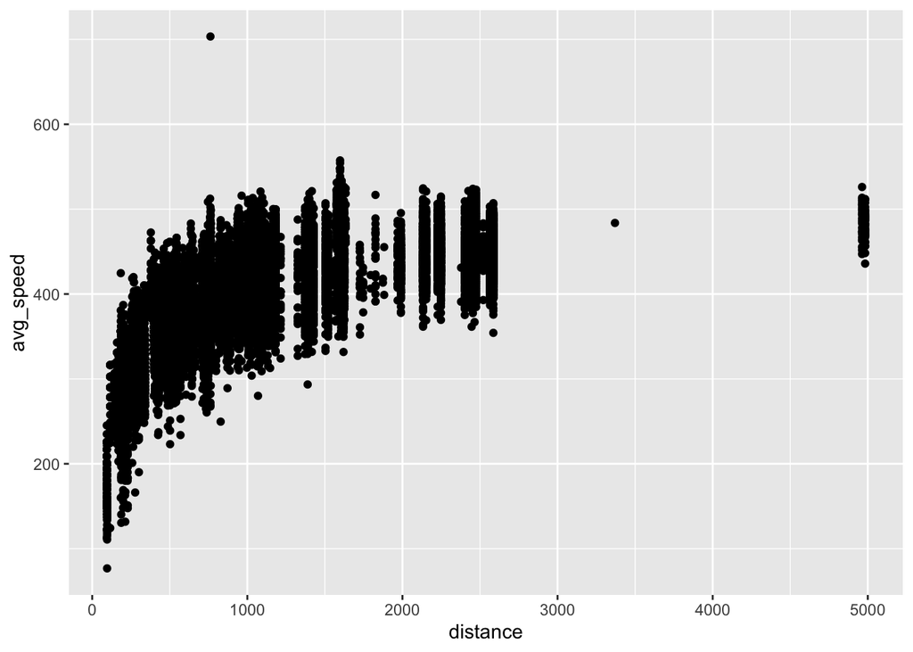

```r
ggplot(nycflights, aes(x = distance, y = avg_speed)) +
  geom_point()
```

### Exercise 9

The latest you can depart and still arrive on time looks to be around 66 minutes

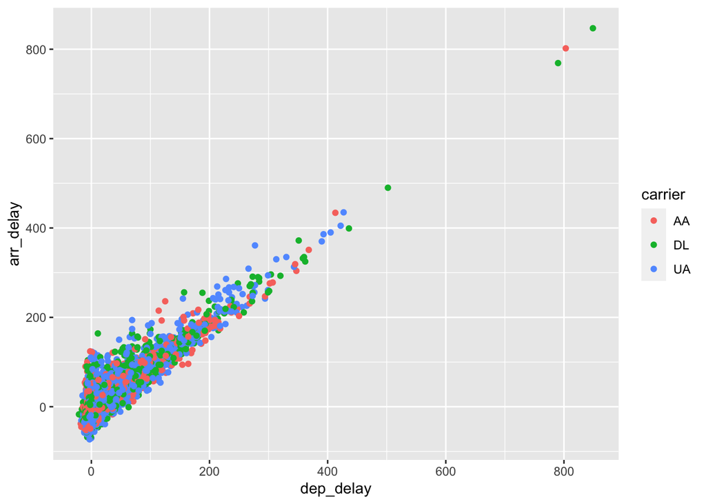

```r
aaDlUaFlights <- nycflights %>%
  filter(carrier %in% c("AA", "DL", "UA"))

ggplot(aaDlUaFlights, aes(x = dep_delay, y = arr_delay, color = carrier)) +
  geom_point()
```